# Subsampling the Triton datase - Temporal rarefaction

# Occurrences and lineages through time (raw data)

`OTT` measures the number of occurrences at each time point directly from their ages. `expertLTT` and `empiricalLTT` capture lineage counts, with the former based on speciation and extinction dates, while the latter depends on observations (first and last appearances).

Plot the number of occurrences and lineages through time

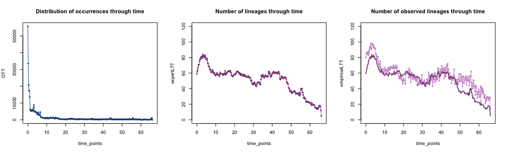

# LTT subsampling

Standardize the number of occurrences by the number of lineages, and subsample to erase the sampling bias. Subsampling is done by calculating the probability for each row, interpolating for time points between values, and subsampling accordingly.

```
               0    10    20    30    40    50    60   70
triton    260000 77000 25000 19000 17000 13000 11000 2600
triton.ss  16000 24000 20000 17000 16000 13000  9100 1100
```

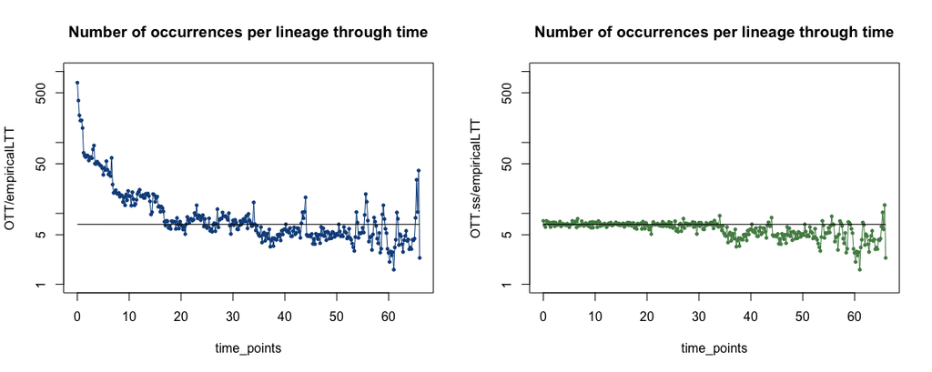

One problem with this method is that it requires having a comprehensive and reliable estimate of the number of lineages through time from experts, which is not available for most clades.

# SQS subsampling

[output not shown]

[output cut: 245 more lines]

[output not shown]

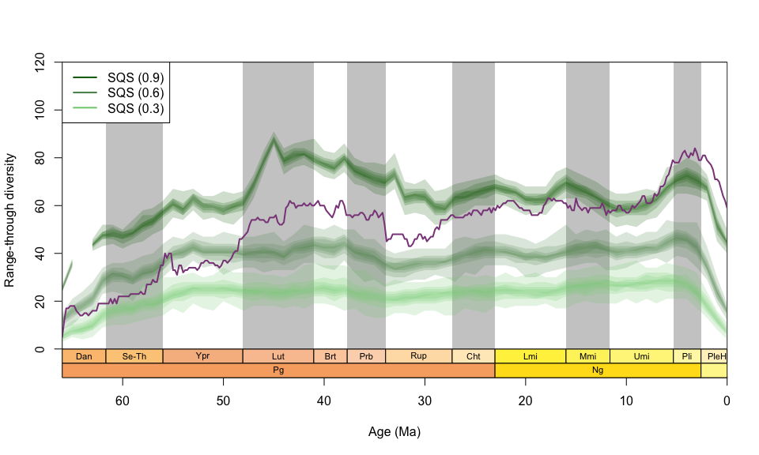

These SQS diversity curves don’t seem to be a great match to the reference LTT.

# Geographic subsampling

## Null model of fossil sampling based on plate technotics

This part processes plate tectonic data to model water depths over the Cenozoic.

[output not shown]

[figure not shown]

**Geographic null model**: Uniform sampling of marine points from each depth raster in cells deeper than 200m, drawing in each bin the same number of occurrences as in Triton, to simulate random sampling of fossils across the Cenozoic.

[output not shown]

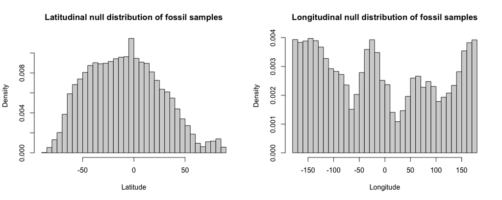

Null distributions of latitude and longitude for the uniformly sampled fossils, allowing a comparison of uniform fossil sampling with actual fossil occurrences.

[output not shown]

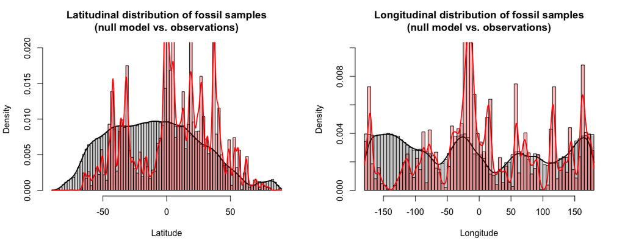

Let’s subsample by optimizing the sampling probability based on deviations from the expected distributions over time, latitude and longitude.

[output not shown]

```
                 0    10    20    30    40    50    60   70
triton      260000 77000 25000 19000 17000 13000 11000 2600
triton.ss6   15000 26000 18000 17000 14000 13000  8600  650
triton.ss15   2300  3400  2300  1900  2000  1900  1300   59
triton.ss20    570   850  1000   600   750   720   450    7
```

[output not shown]

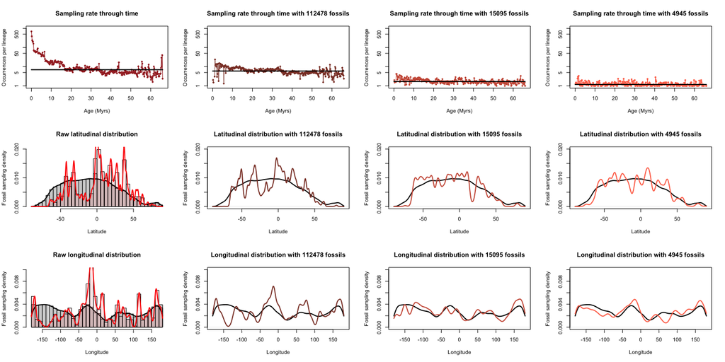

This method reduces the temporal and geographical biases, but requires again to know the expected temporal richness trajectory. Let’s try a subsampling method that does not use this information.

# Hole-based subsampling

In this section, we aim to reduce sampling biases in our dataset by performing subsampling based on drilling holes (locations where fossils were collected). The goal is to achieve a more uniform sampling effort across different holes and through time.

## Calculating Occurrence Density per Hole

[output not shown]

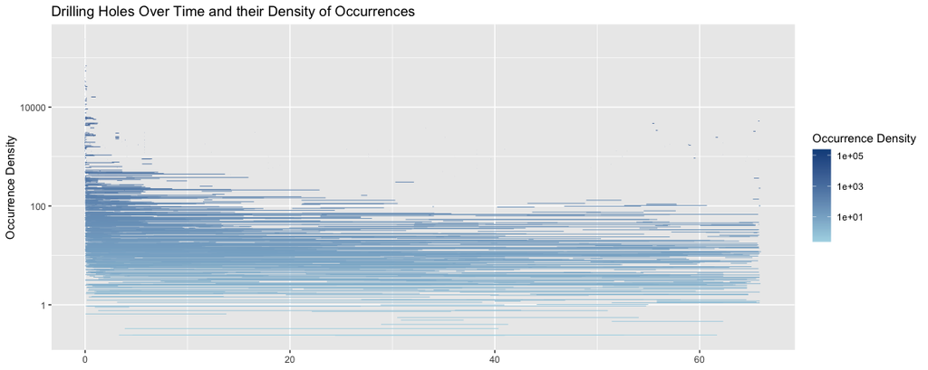

This plot highlights holes with unusually high densities that may introduce sampling bias.

## Subsample at the Sediment Sample level

In this section, we focus on subsampling at the sample level to reduce sampling biases by homogenizing the number of sediment samples per hole through time. This method aims to create a more balanced dataset by adjusting for overrepresented holes and time periods.

### Visualizing the Occurrence Density per Sample and the Sample Density per Hole

- `HoleNbSample`: Number of unique samples collected from each hole.
- `HoleDtySample`: Density of samples per hole, adjusted for the duration of sampling at each hole.
- `STT`: Number of samples collected at each time point.

[output not shown]

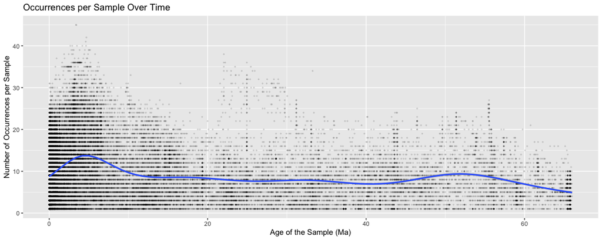

The mean number of occurrences per sample looks much more like the distribution of species over time. Let’s look at this quantity directly.

- `SpHTT` = Samples per hole through time
- `OpSTT` = Occurrences per sample through time

[output not shown]

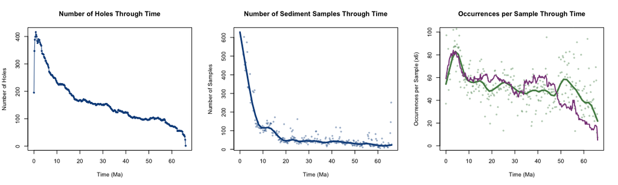

### Subsampling - Homogenize the Number of Samples Through Time (ss.STT)

[output not shown]

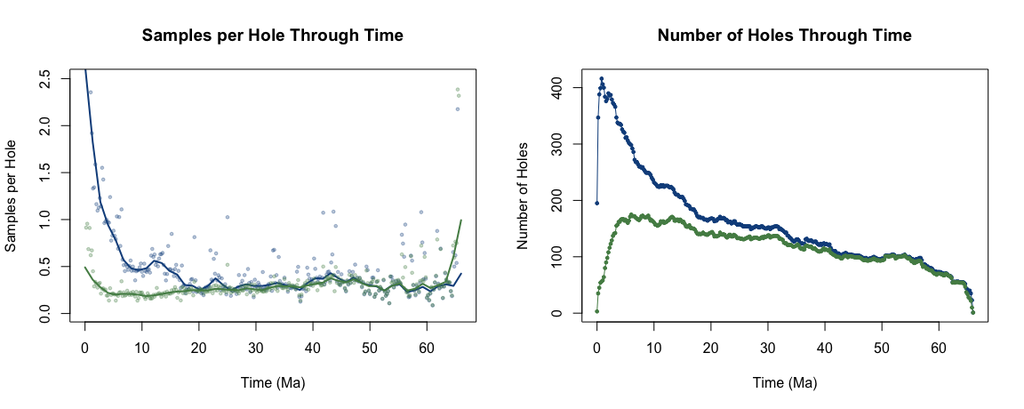

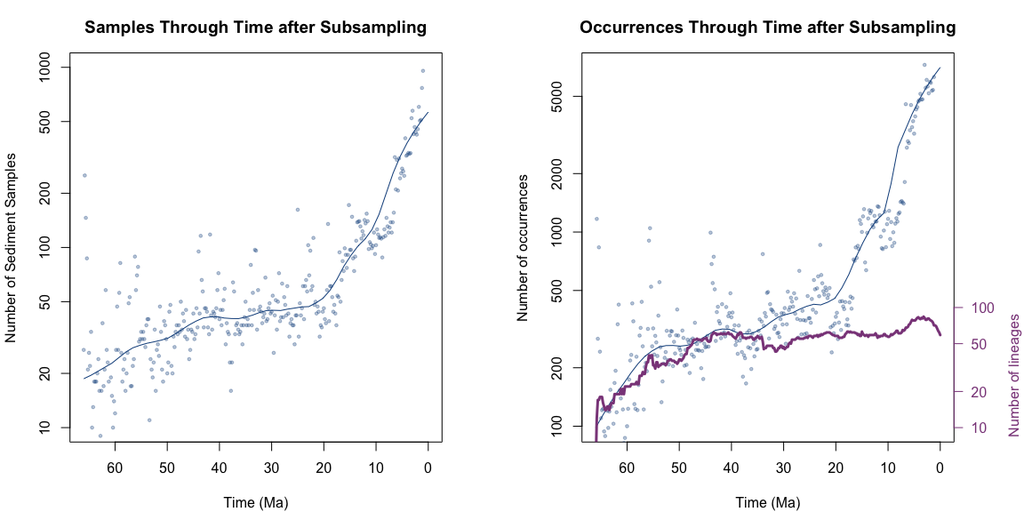

[output not shown]

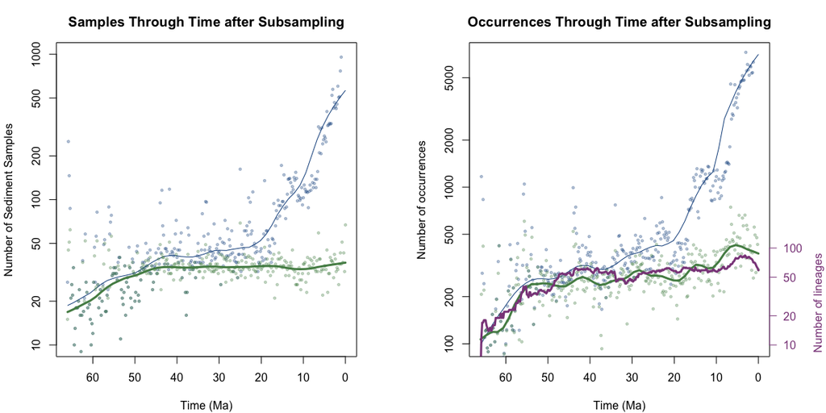

[output not shown]

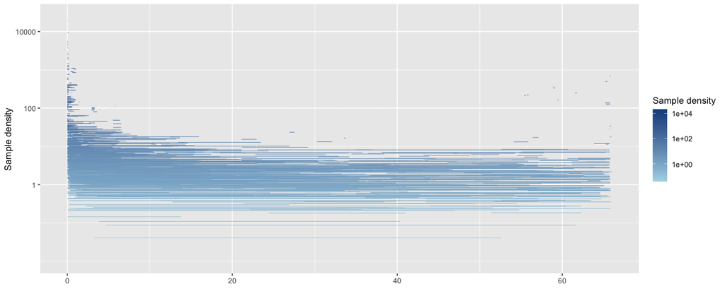

[output not shown]

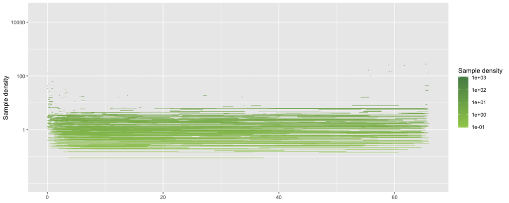

## Check spatial biases

[output not shown]

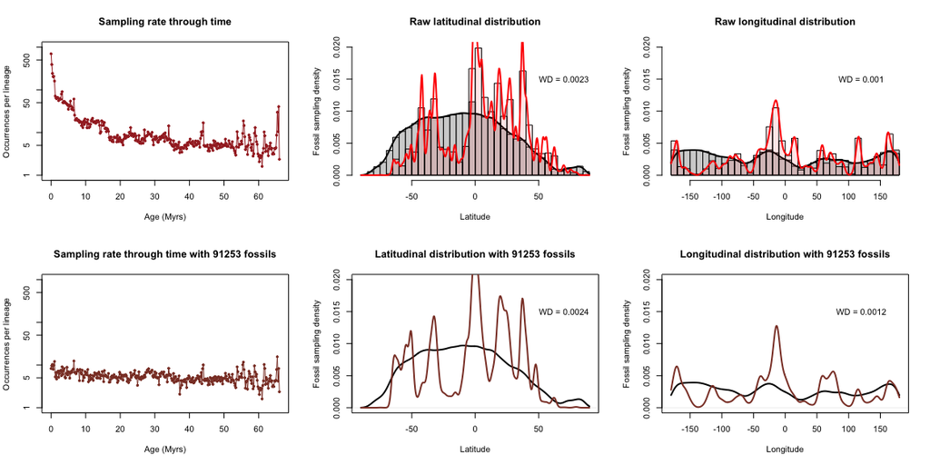

## Compare to simulated homogeneous sampling

[output not shown]

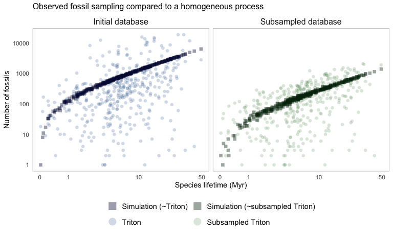

# Save objects

```
NA
```

```
NA
```